# C9.8 湾曲外板パネルの座屈強度、補強された湾曲外板構造の極限強度

### 一般的なコメント:-

一般に、圧縮応力はパネル座屈を引き起こす支配的な要因である。したがって、パネルの座屈応力を増加させ、また曲げモーメントを支持するためのより効果的なストリンガー配置にするためには、断面の上部および下部領域ではストリンガーの間隔を狭く配置し、中立軸に近づくにつれて間隔を広くする必要がある。

### 問題 2.

問題1の胴体セクションは、5 psiの内圧（外向き）を受けている。この内圧が存在する場合の、パネルの圧縮座屈応力および剪断座屈応力はいくらになるか。

### 解答.

C9.6節より、相互作用方程式は、

$$R_c^2 + R_p = 1, \quad R_c = \frac{f_c}{F_{c_{cr}}}$$

問題1より、圧縮座屈応力 $F_{c_{cr}} = 7850 \text{ psi}$ である。

$R_p$ を評価するには、湾曲外板パネルの半径と等しい半径を持つ円筒に座屈を生じさせる外側から内向きに作用する動径方向の圧力を決定する必要がある。このような荷重下での座屈応力を決定するために、第C8章の Fig. C8.16 を使用する。Fig. C8.16 の下部スケールパラメータは、

$$Z_L = \frac{L^2}{rt} \sqrt{1 -
u_e^2}$$

$$= \frac{15.75^2}{20 \times .04} \sqrt{1 - .3^2} = 296$$

Fig. C8.16 より、 $K_y = 19$ を読み取る。

$$F_{c_{cr}} = \frac{K_y \pi^2 E}{12 (1 -
u_e^2)} \left(\frac{t}{L}\right)^2$$

$$= \frac{19 \pi^2 \times 10,700,000}{12 (1 - .3^2)} \left(\frac{.04}{15.75}\right)^2 = 1215 \text{ psi}$$

この座屈応力を生じさせる外側の動径方向圧力は、

$$p = F_{c_{cr}} t / r = 1215 \times .04 / 20 = 2.43 \text{ psi}$$

$$R_p = \frac{5.0}{2.43} = 2.06$$

$R_p$ にマイナス符号をつけて相互作用方程式に代入する。

$$\frac{f_c^2}{F_{c_{cr}}^2} - R_p = 1$$

$$\frac{f_c^2}{7850^2} - 2.06 = 1, \quad \text{または} \quad f_c = 13750 \text{ psi}$$

したがって、5 psiの内向きから外向きへの内圧により、軸圧縮座屈応力は 7850 から 13750 psi に増加する。

#### 5 psiの内圧（動径方向）下での剪断座屈応力

C9.7節より、相互作用方程式は、

$$R_s^2 + R_p = 1$$

問題1より、我々のパネルの $F_{s_{cr}}$ は 11200 psi であった。 $R_p$ の値は上記と同様に決定され、 $R_p = 2.06$ である。相互作用方程式に代入すると、

$$\frac{f_s^2}{F_{s_{cr}}^2} - 2.06 = 1$$

$$f_s^2 = 11200^2 (3.06), \quad \text{または} \quad f_s = 19500 \text{ psi}$$

このように、5 psiの内圧により、剪断座屈応力は 11200 から 19500 psi に増加する。

# パート 2. 補強された円筒構造の極限強度

## C9.9 イントロダクション

薄い外板で覆われ、縦方向のストリンガーと横方向のフレームまたはリングによって補強された円筒構造は、飛行機の胴体、ミサイル、および様々なタイプの宇宙物体の一般的な構造形式であり、このような構造はしばしばセミモノコック構造と呼ばれる。セミモノコック構造の設計には、2つの主要な課題の解決が含まれる。すなわち、様々な外荷重下での構造内の応力分布の決定と、これらの応力が構造全体だけでなく構造の個々の構成要素によって安全かつ効率的に支持できるかどうかの検証である。

## C9.10 セミモノコック構造の不安定破損のタイプ

### (1) 外板の不安定性

一般に、薄い湾曲外板パネルは比較的低い圧縮応力で座屈する。したがって、設計要件で制限荷重または設計荷重の下で外板の座屈を許容しないと規定されている場合、外板を比較的厚くするか、ストリンガーを非常に接近して配置する必要があり、胴体や機体構造は強度重量の観点から不満足なものになる。ミサイル構造では、内圧付加によって座屈応力が大幅に増加するため、薄い外板の座屈の弱さは改善されるが、すべての運転条件下で構造を加圧状態に維持することには困難が伴う。

セミモノコック体では、縦方向のストリンガーが圧縮応力に対して効率的な抵抗を提供し、座屈した外板パネルは斜め張力場作用によって剪断荷重を伝達できるため、外板パネルの座屈は構造ユニット全体の極限強度を制限する重要な要因にはならない。外板パネルの座屈が発生すると、構造全体に応力の再分配が行われるため、外板の座屈がいつ始まるかを知ることは重要である。さらに、設計要件において、制限荷重または設計荷重の特定の割合以下では外板の座屈が発生してはならないと規定されることも多い。本章の第1パートの方程式および設計曲線は、様々な応力状態における湾曲外板パネルの座屈応力を決定するために使用できる。

### (2) パネルの不安定性

胴体などのセミモノコック構造における内部のリングまたはフレームは、縦方向のストリンガーとそれに付随する外板を「パネル」と呼ばれる長さに分割する。これらのフレームが十分に剛性である場合、曲げを受けるセミモノコック構造は、Fig. C9.7a に示すように圧縮側で破損する。ストリンガーは、リング間隔に等しい有効長を持つ柱として機能する。したがって、初期破損は単一のパネルで発生し、パネル不安定破損と呼ばれる。一般に、実用的な航空機および宇宙往還機のセミモノコック構造の大部分では、リングがこのタイプの破損を促進するのに十分な剛性を持っているため、このタイプの破損が発生する。胴体の内部には乗客や貨物などの様々な荷重が積載されるため、リングはこれらの荷重を外板シェルに伝達するための構造ユニットとして機能しなければならず、したがってかなりの強度と剛性を持つリングが必要となる。軽荷重のフレームであっても、リング断面のウェブを通過する様々なシステムに必要な配管類を通すために数インチの深さが必要であり、これにより、柱として機能する補強材を支持するための比較的剛性の高いリングが提供される。外板が剪断および圧縮応力の下で座屈すると、外板パネルは半斜め張力場作用によってさらに剪断力を伝達し、これによりストリンガーに追加の軸荷重が発生し、さらにパネルの破損強度に到達する際に考慮しなければならない曲げが発生する。この主題は、第C11章のパート2で詳細に扱われる。

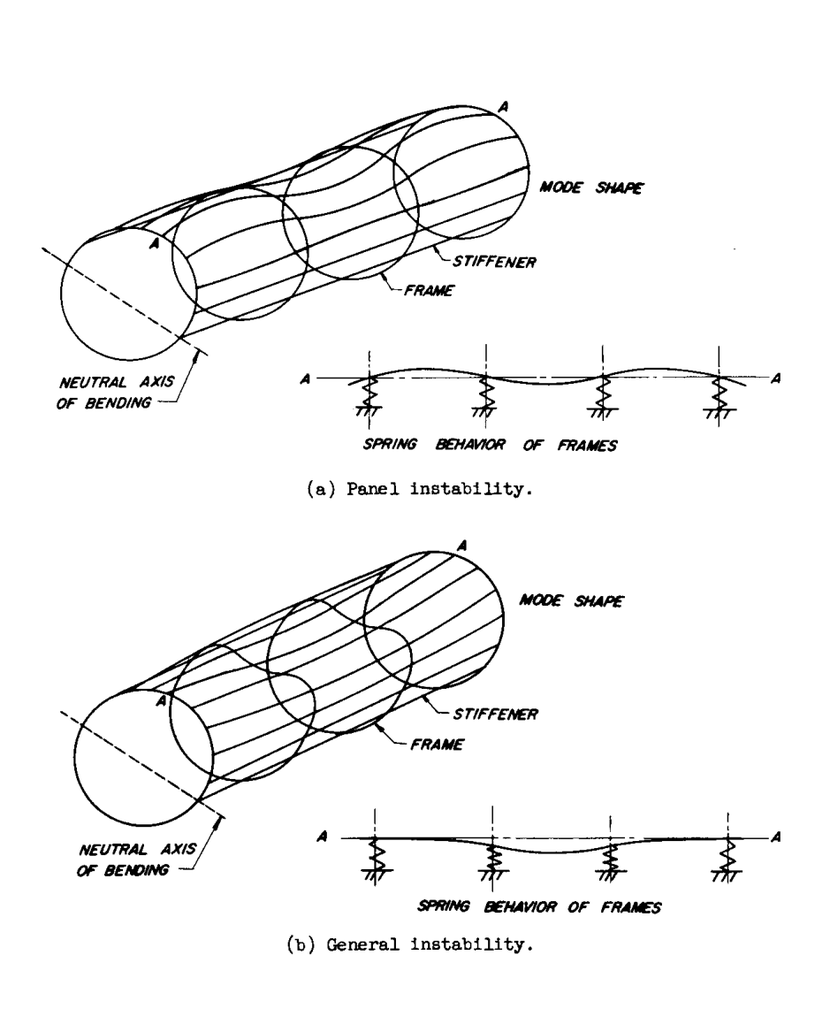

パネル不安定性と全体不安定性

### (3) 全体不安定性

全体不安定性においては、破損は隣接する2つのフレームまたはリングの間の領域に限定されず、曲げを受ける補強円筒シェルについて Fig. C9.7b に示すように、複数のフレーム間隔にわたって広がる可能性がある。パネル不安定性においては、フレームまたはリングによって提供される横方向の補強材は、Fig. C9.7a に示すように、フレーム支持点においてストリンガーに節を強制するのに十分である。この量を超える追加の補強材は、追加の座屈強度には寄与しない。したがって、支持フレームの補強材がこの最小値未満である場合に、全体不安定性が発生する可能性がある。

## C9.11 外荷重下における補強円筒構造の応力決定

典型的な胴体やミサイルの設計に使用されるような補強円筒構造内の応力は、第A20章で説明されている修正梁理論によってかなり正確に決定できる。より厳密なアプローチは、マトリックス定式化を含む第A8章で示されているが、このアプローチでは必要な計算を処理するために大型電子計算機を使用する必要がある。修正梁理論の適用の詳細については、第A20章のA20.3節およびA20.4節を参照されたい。A20.4節に示されている例題の解答では、湾曲外板に使用する有効面積は、設計荷重下での胴体全体の有効断面の曲げによるパネルへの曲げ圧縮応力に対する、湾曲パネルの座屈応力の比に基づいていた。Table A20.2 に示されている例題では、湾曲パネルに対して $0.3 E t/r$ に等しい保守的な圧縮座屈応力が使用され、圧縮座屈応力に対する剪断応力の影響は考慮されていなかった。

より正確な手順は、パネルの座屈強度に対する複合圧縮と剪断の影響を考慮して、湾曲パネルの有効面積を計算することである。したがって、第A20章のA20.5ページの Table A20.2 において、各湾曲パネルの剪断応力も計算し、その後、複合圧縮と剪断の下でのパネルの座屈応力を計算する必要がある。

純粋圧縮下の座屈応力と剪断は、式C9.1およびC9.2を使用して計算する必要がある。複合圧縮と剪断の下での座屈応力は、以下の相互作用方程式によって与えられる：

$$R_c + R_s^2 = 1, \quad \text{ここで} \quad R_c = f_c/F_{c_{cr}}, \quad R_s = f_s/F_{s_{cr}}$$

安全余裕（M.S.）の式は、

$$\text{M.S.} = \frac{2}{R_c + \sqrt{R_c^2 + 4R_s^2}} - 1$$

作用する圧縮応力と剪断応力の比が一定である場合に、複合圧縮と剪断を受けたときに湾曲外板パネルが座屈する圧縮応力を $\bar{f}_c$ とする。このとき、

$$\bar{f}_c = f_c \left( \frac{2}{R_c + \sqrt{R_c^2 + 4R_s^2}} \right) \quad \text{--- C9.6}$$

これらの $\bar{f}_c$ の値は、Table A20.2 の第5列の値を置き換える必要がある。

著者は、ある航空宇宙会社がミサイル設計において、座屈した湾曲パネルの有効面積を計算する際、理論上の座屈応力の90パーセントしか使用していないことに注目した。この修正は、胴体セクション全体がさらに荷重を受け、湾曲外板がより大きな座屈変形を被るにつれて、湾曲外板パネルが座屈応力を維持できなくなると想定している。

## C9.12 パネル不安定強度

パネル不安定性とは、隣接する2つのフレーム間におけるストリンガーとその有効外板の破損を意味する。補強されたシェル全体の曲げは、ストリンガーに圧縮荷重または応力を発生させる。座屈後の外板の半張力場作用は、ストリンガーに追加の圧縮荷重と曲げモーメントを発生させる。

補強されたシェル全体の曲げによる圧縮応力は、C9.11節で説明した方法によって求められる。半張力場作用による追加のストリンガー荷重は、第C11章のパート2に示されている理論と手順によって決定される。

これらの計算されたストリンガー荷重をストリンガー強度と比較して、正の安全余裕が存在するかどうかを判断する。ストリンガーとその有効外板の局所的なクリップリング強度および柱強度は、第C7章に示されている理論と解析方法によって求めることができる。ストリンガー断面の曲げ強度は、第C3章に示されている理論と解析方法によって求めることができる。複合圧縮と曲げにおけるストリンガーの強度は、適切な相互作用方程式を使用することによって求められる。

## C9.13 全体不安定性の計算

補強されたシェルの全体不安定性の主題に関しては、多くの理論的および実験的研究が行われてきた。このような構造の設計における全体的な目標は、Fig. C9.7b に示すようなタイプの破損を防ぐ、言い換えれば、パネル不安定性である Fig. C9.7a に示すような破損のタイプを確実にするために、フレームが十分な剛性を持つようにすることである。

Shanley (Ref. 6) は、純曲げにおける補強円筒シェルの全体不安定破損を防ぐために必要なフレーム剛性の式を導き出した。

$$(EI)_f = C_f M D^2 / L$$

利用可能な試験データの研究において、 $C_f$ は 1/16000 であることが分かった。したがって、

$$(EI)_f = M D^2 / 16000 L \quad \text{--- C9.7}$$

ここで、 * $E$ = 弾性係数 * $I$ = フレーム断面の慣性モーメント * $D$ = 補強されたシェルの直径 * $L$ = フレーム間隔 * $M$ = シェルに作用する曲げモーメント

Becker (Ref. 7) は、補強されたシェルの全体不安定性に関する、公表されているほとんどの理論的および実験的資料の包括的な研究において、彼の研究結果を Table C9.1 のように要約している。

#### 曲げ

曲げの場合、Table C9.1 に示されている式中の定数 4.80 は、フレームがストリンガー間の外板に取り付けられている条件に対するものである。フレームがストリンガー間の外板に取り付けられていない場合、定数は 3.25 とすべきである。

ストリンガーと共に使用する有効外板幅は、以下の式から求められる。

$$\frac{W_e}{b} = 0.5 (F_{c_{cr}} / F_c)^{1/2} \quad \text{--- C9.8}$$

ここで、 * $W_e$ = ストリンガーの片側あたりの外板の有効幅 (in.) * $b$ = ストリンガー間隔 (in.) * $F_{c_{cr}}$ = 湾曲外板パネルの圧縮座屈応力 * $F_c$ = 曲げ全体不安定性における圧縮応力 (psi)

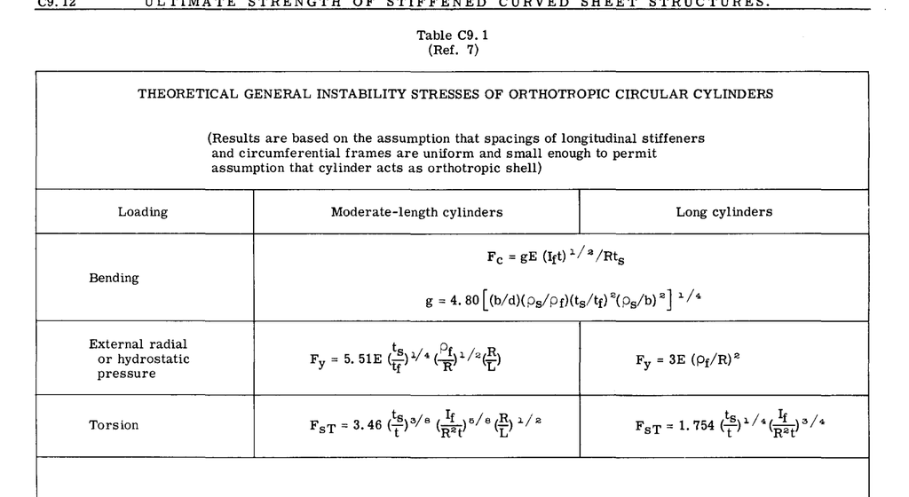

直交異方性円筒の理論的全体不安定応力

フレームについては、有効外板幅は全フレーム間隔（ $d$ ）として扱う必要がある。非弾性応力については、限られた試験データに基づき、割線弾性係数の使用が適用可能であると思われる。

#### 外側の動径方向圧力または静水圧

ストリンガーおよびフレームの断面特性を計算する際に使用する有効外板幅は、以下の式から決定できる。

$$\frac{W_{e_s}}{b} = \frac{W_{e_f}}{d} = 0.5 (F_{c_{cr}} / F_c)^{1/2} \quad \text{--- C9.9}$$

下付き文字 $s$ はストリンガーを指し、 $f$ はフレームを指す。記号 $d$ はフレーム間隔である。

#### ねじり

使用する有効外板は、以下の式から決定できる：

$$\frac{W_{e_s}}{b} = \frac{W_{e_f}}{d} = 0.5 (F_{s_{cr}} / F_{st})^{1/2} \quad \text{--- C9.10}$$

ここで、 $F_{s_{cr}}$ は湾曲外板パネルの剪断座屈応力である。 $F_{st}$ は、ねじり全体不安定性におけるねじり剪断応力 (psi) である。

Table C9.1 に示されているねじりの式は、フレームに重大な二次応力を導入する可能性のある強い張力場が存在するシェルには適用されない。読者は、外板パネルにおける半張力場作用の影響を含むこの主題の取り扱いについて、第C11章のパート2を参照されたい。

#### 横剪断全体不安定性

Ref. 7 より、保守的な剪断全体不安定剪断応力は、以下の関係を利用して設定できると述べられている。

$$F_s = 0.85 F_{st} \quad \text{--- C9.11}$$

ここで、 $F_s$ は横剪断全体不安定性における横剪断応力である。

#### 複合ねじりと曲げにおける全体不安定性

Ref. 7 より、補強された円筒への許容可能な作用ねじりモーメントと曲げモーメントの組み合わせを計算するために、以下の相互作用関係を使用できる。

$$M / M_0 + (T / T_0)^2 = 1 \quad \text{--- C9.12}$$

ここで、 * $M$ = 作用曲げモーメント * $M_0$ = 単独で作用する曲げ全体不安定性を引き起こすモーメント * $T$ = 作用ねじりモーメント * $T_0$ = 単独で作用するねじり全体不安定性を引き起こすねじりモーメント

#### 複合横剪断と曲げにおける全体不安定性

Ref. 7 は、横剪断と曲げ荷重のこの組み合わせに対しては相互作用がないと結論づけている。全体不安定性は、どちらのタイプの荷重が単独で作用する場合にのみ発生するため、両方の荷重を個別に検証することができる。

## C9.14 一様外圧を受ける球面の座屈

ポアソン比に 0.3 を使用した古典理論は、一様な外圧を受ける完全な球面シェルに対して以下の座屈応力を与える：

$$F_{cr} = 0.606 E t/r \quad \text{--- C9.13}$$

実際のシェルに関する利用可能な試験データは、この理論上の座屈応力が非常に高すぎることを示している。したがって、実験結果を満たすためには、低減された値を使用しなければならない。外圧下での湾曲板の式に類似した座屈式は、以下の通りである（Ref. 2 より）：

$$F_{cr} = \frac{K_p \pi^2 E}{12 (1 -
u_e^2)} \left(\frac{t}{d}\right)^2 \quad \text{--- C9.14}$$

Fig. C9.8 は座屈係数 $K_p$ を決定するための曲線を示しており、試験データが理論上の座屈曲線よりかなり下回っていることを示している。式C9.14は、材料の比例限度応力を下回る座屈応力に対するものである。

General Dynamics Corp. の Astronautics Division のレポート AS-D-568 は、試験データの統計的研究から、予備設計で使用するための一様外圧下の球面シェルの座屈応力に対して以下の式を与えている。

平均期待値に対して：

$$F_{cr} = \frac{0.1561 E t}{r (\sin \alpha)^{1/3}} \quad \text{--- C9.15}$$

確率 = 90 パーセント、および信頼係数 0.95 に対して：

$$F_{cr} = \frac{0.1138 E t}{r (\sin \alpha)^{1/3}} \quad \text{--- C9.16}$$

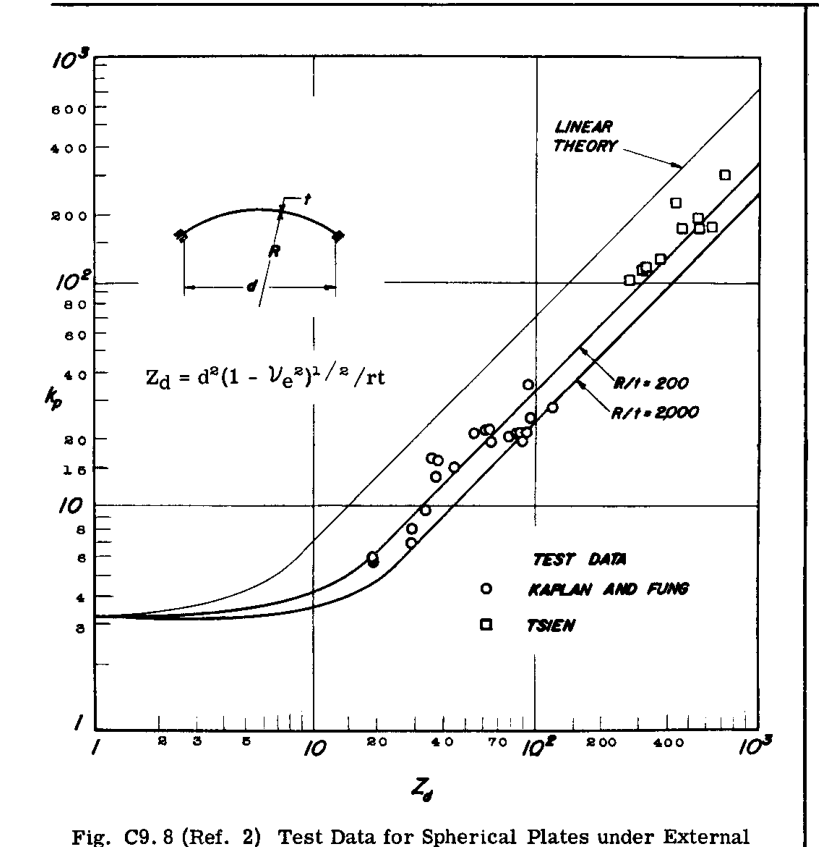

試験データと実験理論の比較

確率 99 パーセント、および信頼係数 0.95 に対して：

$$F_{cr} = \frac{0.0908 E t}{r (\sin \alpha)^{1/3}} \quad \text{--- C9.17}$$

角度 $\alpha$ の説明については、Fig. A を参照。

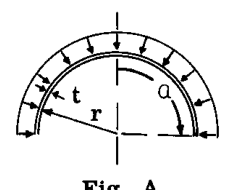

角度アルファの説明

$\alpha = 90$ または半球の場合、 $(\sin \alpha)^{1/3}$ は 1 である。

カバーされた試験範囲は、

$$70^\circ \le \alpha \le 90^\circ$$

$$175 \le r/t \le 2000$$

方程式は、材料の比例限度応力を下回る座屈応力に対するものである。

## 問題

1. 例題1の Fig. C9.6 に示されている胴体断面は、外板の厚さを .05 インチに増やすことによって変更されている。設計荷重は以下の値に増加される：

$$M_y = 700,000 \text{ in. lb.}, \quad V_z = 6040 \text{ lbs.}$$

$$T = 245,000 \text{ in. lb.}$$

この複合荷重下で、外板パネルのいずれかが座屈するか。

2. 上記の問題1で与えられた胴体セクションは、 6 psi の内圧（外向き）を受ける。この内圧下での外板パネルの圧縮座屈応力および剪断座屈応力はいくらになるか。

## 参考文献

1. Schildcrout & Stein. Critical Combinations of Shear and Direct Axial Stress for Curved Rectangular Panels. NACA T.N. 1928.
2. Gerard & Becker. Handbook of Structural Stability. Part III. Buckling of Curved Plates and Shells. NACA T.N. 3883.
3. Rafel & Sandlin. Effect of Normal Pressure on the Critical Compression and Shear Stress of Curved Sheet. NACA WRL-57.
4. Rafel. Effect of Normal Pressure on the Critical Compressive Stress of Curved Sheet. NACA WRL-258.
5. Brown & Hopkins. The Initial Buckling of a Long and Slightly Curved Panel under Combined Shear and Normal Pressure. R&M No. 2766, BRITISH ARC (1949).
6. Shanley F.R. Simplified Analysis of General Instability of Stiffened Shells in Pure Bending. Jour. of Aero. Sciences, Vol. 16, Oct. 1949.
7. Becker H. Handbook of Structural Stability. Part VI. Strength of Stiffened Curved Plates and Shells. NACA T.N. 3786.